# Assignment 6

In this assignment, you'll analyze a collection of data sets from the [San Francisco Open Data Portal](http://data.sfgov.org/) and [Zillow](https://www.zillow.com/). The data sets have been stored in the SQLite database `sf_data.sqlite`, which you can [download here](http://anson.ucdavis.edu/~nulle/sf_data.sqlite). The database contains the following tables:

| Table | Description |
| --- | --- |
| `crime` | Crime reports dating back to 2010. |
| `mobile_food_locations` | List of all locations where mobile food vendors sell. |
| `mobile_food_permits` | List of all mobile food vendor permits. More details [here](https://data.sfgov.org/api/views/rqzj-sfat/files/8g2f5RV4PEk0_b24iJEtgEet9gnh_eA27GlqoOjjK4k?download=true&filename=DPW_DataDictionary_Mobil… |
| `mobile_food_schedule` | Schedules for mobile food vendors. |
| `noise` | Noise complaints dating back to August 2015. |
| `parking` | List of all parking lots. |
| `parks` | List of all parks. |
| `schools` | List of all schools. |
| `zillow` | Zillow rent and housing statistics dating back to 1996. More details [here](https://www.zillow.com/research/data/). |

The `mobile_food_` tables are explicitly connected through the `locationid` and `permit` columns. The other tables are not connected, but you may be able to connect them using dates, latitude/longitude, or postal codes.

Shapefiles for US postal codes are available [here](https://www.census.gov/geo/maps-data/data/cbf/cbf_zcta.html). These may be useful for converting latitude/longitude to postal codes.

Shapefiles for San Francisco Neighborhoods are available [here](https://data.sfgov.org/Geographic-Locations-and-Boundaries/SF-Find-Neighborhoods/pty2-tcw4).

```python
import pandas as pd
from matplotlib import pyplot as plt
import sqlalchemy as sqla
import sqlite3
%matplotlib inline
plt.style.use('ggplot')
import pandas as pd
import matplotlib.patches as mpatches
import numpy as np
from pylab import *
import seaborn as sns
sns.set(style="whitegrid")
```

**Exercise 1.1.** Which mobile food vendor(s) sells at the most locations?

```python
sqlite_file = 'sf_data.sqlite'
SF_conn = sqlite3.connect(sqlite_file)
SF_conn
```

```
<sqlite3.Connection at 0x12d949770>
```

```python
c = SF_conn.cursor()

# Create table
query = c.execute("SELECT Applicant, COUNT(Applicant) AS NumberOfLocations FROM mobile_food_permits GROUP BY Applicant ORDER BY COUNT(Applicant) DESC")
query.fetchall()[0:2]
```

```
[(u'Roadside Rotisserie Corporation / Country Grill', 7),
 (u"San Francisco Carts & Concessions, Inc. DBA Stanley's Steamers Hot Dogs",
  6)]
```

**Exercise 1.2.** Ask and use the database to analyze 5 questions about San Francisco. For each question, write at least 150 words and support your answer with plots. Make a map for at least 2 of the 5 questions.

You should try to come up with some questions on your own, but these are examples of reasonable questions:

- Which parts of the city are the most and least expensive?
- Which parts of the city are the most dangerous (and at what times)?
- Are noise complaints and mobile food vendors related?
- What are the best times and places to find food trucks?
- Is there a relationship between housing prices and any of the other tables?

Please make sure to clearly state each of your questions in your submission.

# Question 1: Most and Least Expensive Neighborhoods

In order to analyze which neighborhoods are the most and least expensive in San Francisco, I used the median of the Median Sold Price per Square Foot variable in the data from Zillow. I queried this database to get the columns MedianSoldPricePerSqft_AllHomes and RegionName. I turned this information into a data frame grouped by RegionName. I then made a bar graph using seaborn of the top 5 most expensive zip code regions, by median of the median sold price per square foot. The least expensive region was Hunters Point, as one might guess, at just under 300 dollars per square foot. The most expensive region was the portion of the Financial District along Market Street, at nearly 1400 dollars per square foot. This region was significantly more expensive than the next most expensive area, which was the South of Market along the Embarcadero, at a median of 800 dollars per square foot.

This is the most appropriate measure for determining how expensive a neighborhood is because the median of the median sold price per square foot controls for outliers, size of the house, and cost.

```python
query = c.execute("SELECT RegionName, MedianSoldPricePerSqft_AllHomes FROM zillow")
zipCodeWithMedians = query.fetchall()
zipCodeWithMedians = pd.DataFrame(zipCodeWithMedians, columns = ("ZipCode", "MedianPrice"))
ByZip = zipCodeWithMedians.groupby('ZipCode').median()
ByZip = ByZip.sort("MedianPrice")
#Extract top and bottom five entries
ByZipMax = ByZip.iloc[0:5]
ByZipMin = ByZip.iloc[21:]
ByZipMax.reset_index(level=0, inplace=True)
ByZipMin.reset_index(level=0, inplace=True)
```

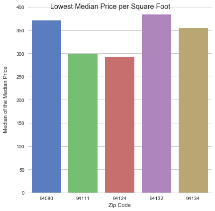

```python
#Bar Graph for top and bottom entries
g = sns.factorplot(x="ZipCode", y="MedianPrice", data=ByZipMax,
                       size=6, kind="bar", palette="muted")
g.despine(left=True)
g.fig.suptitle("Lowest Median Price per Square Foot\n")
g.set_ylabels("Median of the Median Price\n")
g.set_xlabels("Zip Code")
```

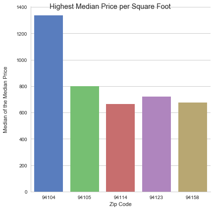

```python
g = sns.factorplot(x="ZipCode", y="MedianPrice", data=ByZipMin,
                       size=6, kind="bar", palette="muted")
#g.despine(left=True)
g.fig.suptitle("Highest Median Price per Square Foot\n")
g.set_ylabels("Median of the Median Price\n")
g.set_xlabels("Zip Code")
```

# Question 2: Most Dangerous Areas and Times in SF

First I plotted a bar graph of the number of reported crimes in each police district to get a sense of which neighborhoods have the most criminal activity. I found that the Southern police district has the highest number of reported crimes at nearly 200,000 reports.

I also made a bar graph of crime report counts across the days of the week to see if crime varies over the week. I found that Friday has the highest overall number of reported crimes at 160,000. I plotted a few of the most common crimes across the hour of the day and found that most crimes hit their low points at 5am, and high point at around 8pm. I plotted vandalism, robbery, assault, and vehicle theft, and found them to vary similarly throughout the day. A graph of these four crime rates showed that their numbers don't vary from month to month, except small spikes in October and in January, possibly from Halloween and New Year's festivities.

```python
query = c.execute("SELECT Category, DayOfWeek, PdDistrict, Datetime, Lon, Lat FROM crime")
crime = query.fetchall()
crime = pd.DataFrame(crime, columns = ("Category", "Day", "District","DateTime", "Lon", "Lat"))
```

```python
collapse_day = crime.groupby("Day").count()
collapse_day.reset_index(level=0, inplace=True)
collapse_day = collapse_day.sort("Category")
```

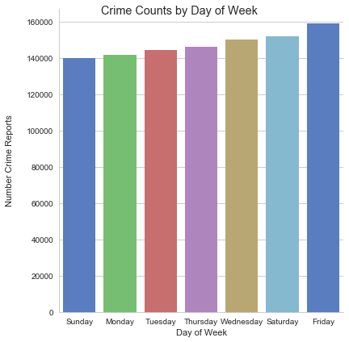

```python
g = sns.factorplot(x="Day", y="District", data=collapse_day,
                       size=6, kind="bar", palette="muted")
#g.despine(left=True)
g.fig.suptitle("Crime Counts by Day of Week\n")
g.set_ylabels("Number Crime Reports\n")
g.set_xlabels("Day of Week")
```

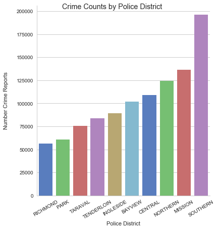

```python
collapse_district = crime.groupby("District").count()
collapse_district.reset_index(level=0, inplace=True)
collapse_district = collapse_district.sort("Category")
collapse_district
g = sns.factorplot(x="District", y="Category", data=collapse_district,
                       size=6, kind="bar", palette="muted")
#g.despine(left=True)
g.fig.suptitle("Crime Counts by Police District\n")
g.set_ylabels("Number Crime Reports\n")
g.set_xlabels("Police District")
g.set_xticklabels(rotation=30)
```

```
Legend
```

[figure not shown]

```python
import seaborn as sns
sns.set(style="whitegrid")

crime["DateTime"] = pd.to_datetime(crime["DateTime"])

group_crime_assault = crime[crime["Category"] == "ASSAULT"].groupby(crime["DateTime"].dt.hour)
plt.plot(group_crime_assault.count(), '#377EB8', label='Assault')

group_crime_vt = crime[crime["Category"] == "VEHICLE THEFT"].groupby(crime["DateTime"].dt.hour)
plt.plot(group_crime_vt.count(), '#55BA87', label='Vehicle Theft')

group_crime_rob = crime[crime["Category"] == "ROBBERY"].groupby(crime["DateTime"].dt.hour)
plt.plot(group_crime_rob.count(), '#7E1137', label='Robbery')

group_crime_vandal = crime[crime["Category"] == "VANDALISM"].groupby(crime["DateTime"].dt.hour)
plt.plot(group_crime_vandal.count(), '#f2b61f', label='Vandalism')

plt.title("Crime Rates by Time of Day")
plt.xlabel("Hour")
plt.ylabel("Number of Crimes")

plt.legend(loc='upper left')
# plt.legend(["Assault", "Vehicle Theft", "Robbery", "Vandalism"], loc='upper left')
plt.show()
```

[figure not shown]

```python
group_crime_assault = crime[crime["Category"] == "ASSAULT"].groupby(crime["DateTime"].dt.month).count()
plt.plot(group_crime_assault)

group_crime_vt = crime[crime["Category"] == "VEHICLE THEFT"].groupby(crime["DateTime"].dt.month)
plt.plot(group_crime_vt.count())

group_crime_rob = crime[crime["Category"] == "ROBBERY"].groupby(crime["DateTime"].dt.month)
plt.plot(group_crime_rob.count())

group_crime_vandal = crime[crime["Category"] == "VANDALISM"].groupby(crime["DateTime"].dt.month)
plt.plot(group_crime_vandal.count())

plt.title("Crime Rates by Month")
plt.xlabel("Month")
plt.ylabel("Number of Crimes")
plt.legend(("Assault", "Vehicle Theft", "Robbery", "Vandalism"))
plt.legend(bbox_to_anchor=(1.05, 1), loc=2, borderaxespad=0.)
plt.show()
```

# Question 3: Do Food Trucks Venture into High Crime Neighborhoods?

```python
#Get food truck locations and hours
query = c.execute("SELECT locationid, EndHour, StartHour, DayOfWeek FROM mobile_food_schedule")
truck_hours = query.fetchall()
truck_hours = pd.DataFrame(truck_hours, columns = ("location", "end", "start", "day"))
late_truck = truck_hours['start'] > 4
late_truck = truck_hours[late_truck]
```

```python
query = c.execute("SELECT locationid, Latitude, Longitude FROM mobile_food_locations")
truck_locs = query.fetchall()
truck_locs = pd.DataFrame(truck_locs, columns = ("location", "long", "lat"))
```

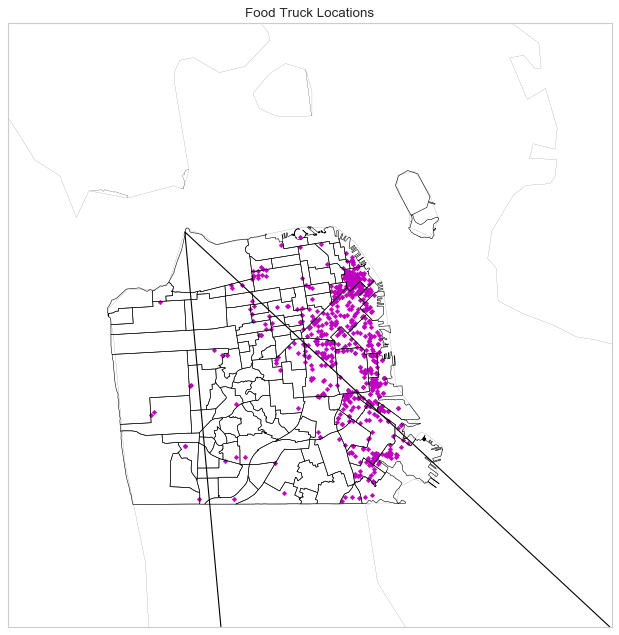

```python
from mpl_toolkits.basemap import Basemap
import matplotlib.pyplot as plt
import scipy.stats as ss
import numpy as np
from matplotlib.patches import Circle, Wedge, Polygon

def draw_SF(figsize = [10,10],dpi=80):
    fig = plt.figure(1, figsize = figsize, dpi = dpi)
    ax = fig.add_subplot(111)

    bmap = Basemap(
        projection='lcc',
        lon_0=-122.4194,
        lat_0=37.7749,
        # in meters
        width=25000,
        height=25000
    )

    bmap.drawcoastlines()
    bmap.drawcounties()
    bmap.readshapefile('./SF Find Neighborhoods/geo_export_c9b3feed-c93d-4ce7-acec-c6a649aa9cd2', 'cityCounties')
    return ax, fig, bmap

ax, fig, bmap = draw_SF()

all_truck_long = [lon for lon in truck_locs['long']]
all_truck_lat = [lat for lat in truck_locs['lat']]

x, y = all_truck_lat, all_truck_long
#x, y = bmap(all_truck_long, all_truck_lat)

# print x, y

bmap.scatter(x, y, 9, marker='D',color='m',latlon=True)

ax.set_title('Food Truck Locations')
plt.show()
```

```python
#Subset to july 2015 larceny reports
query = c.execute("SELECT Category, PdDistrict, Lat, Lon, DateTime FROM crime WHERE Category = 'LARCENY/THEFT'")
crime = query.fetchall()
crime = pd.DataFrame(crime, columns = ("Category", "PdDistrict", "Lat", "Lon", "DateTime"))

crime["DateTime"] = pd.to_datetime(crime["DateTime"])
crime_july15 = crime[crime["DateTime"].dt.year == 2015]
crime_july15 = crime[crime["DateTime"].dt.month == 7]
```

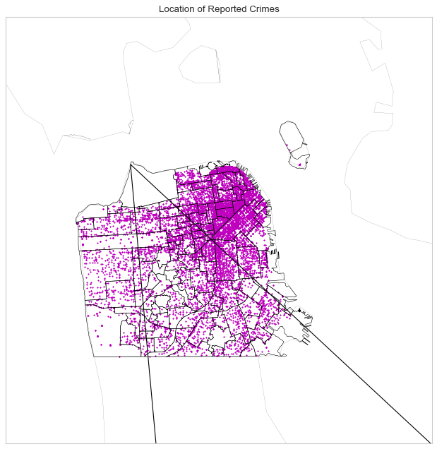

```python
def draw_SF(figsize = [10,10],dpi=80):
    fig = plt.figure(1, figsize = figsize, dpi = dpi)
    ax = fig.add_subplot(111)

    bmap = Basemap(
        projection='lcc',
        lon_0=-122.4194,
        lat_0=37.7749,
        # in meters
        width=25000,
        height=25000
    )

    bmap.drawcoastlines()
    bmap.drawcounties()
    bmap.readshapefile('./SF Find Neighborhoods/geo_export_c9b3feed-c93d-4ce7-acec-c6a649aa9cd2', 'cityCounties') #this tells you to read the aquifrp025 files
    return ax, fig, bmap

ax, fig, bmap = draw_SF()

all_crime_long = [Lon for Lon in crime_july15['Lon']]
all_crime_lat = [Lat for Lat in crime_july15['Lat']]

x, y = all_crime_long, all_crime_lat

bmap.scatter(x, y, 2, marker='D',color='m',latlon=True)

ax.set_title('Location of Reported Crimes')
plt.show()
```

# Question 4: Do food trucks correspond to increased noise violations?

For this question I plotted noise violations and food trucks on the map of San Francisco. At a glance, I do not see any patterns that would relate food trucks with noise violations. It looked like marked street and the Mission district had a strong clustering of both noise violations and food trucks. However, these noise violations contained so many different types of noises, such as construction and traffic sounds, that I wanted to subset the data to get a more accurate picture.

I decided to subset this to the noise types I thought would most likely be correlated with food trucks - major event, entertainment, mechanical noise, and other excessive noise. I plotted these noise violations against food trucks on a second map graph and found that Market and Mission streets definitely show a strong concentration of both food trucks and potentially food truck related noise violations.

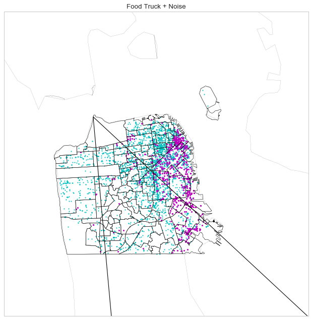

```python
ax, fig, bmap = draw_SF()

all_truck_long = [lon for lon in truck_locs['long']]
all_truck_lat = [lat for lat in truck_locs['lat']]

# get noise
query = c.execute("SELECT Lat, Lon, DateTime FROM noise")
result = query.fetchall()
noise_all = pd.DataFrame(result, columns = ("Lat", "Lon", "DateTime"))

noise_all_long = [lon for lon in noise['Lon']]
noise_all_lat = [lat for lat in noise['Lat']]

# plot noise
bmap.scatter(noise_all_long, noise_all_lat, 9, marker='.',color='c',latlon=True)

# plot food trucks
bmap.scatter(all_truck_lat, all_truck_long, 25, marker='.',color='m',latlon=True)

ax.set_title('Food Truck + Noise')
plt.show()
```

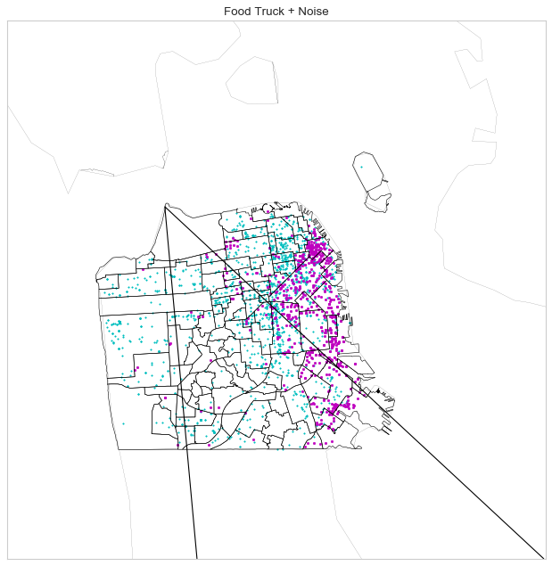

```python
ax, fig, bmap = draw_SF()

all_truck_long = [lon for lon in truck_locs['long']]
all_truck_lat = [lat for lat in truck_locs['lat']]

query = c.execute("SELECT neighborhood, type, Lat, Lon, DateTime FROM noise WHERE type = 'major_event_venue'  OR type = 'entertainment'  OR type = 'mechanical_equipment' OR type = 'other_excessive_noise'")
result = query.fetchall()
noise = pd.DataFrame(result, columns = ("hood", "type", "Lat", "Lon", "DateTime"))

noise_long = [lon for lon in noise['Lon']]
noise_lat = [lat for lat in noise['Lat']]

# plot noise
bmap.scatter(noise_long, noise_lat, 9, marker='.',color='c',latlon=True)

# plot food trucks
bmap.scatter(all_truck_lat, all_truck_long, 25, marker='.',color='m',latlon=True)

ax.set_title('Food Truck + Noise')
plt.show()
```

# Question 5: How Does Crime Change Across Police Districts?

Here I made pie charts of the types of crimes occurring in the highest and lowest crime police districts. I used the bar charts from question 2 to determine that the Richmond District has the lowest number of reported crimes, and the Southern district has the highest.

The first pie chart is of the Richmond district, and shows that the top three most commonly reported crimes are larceny/theft, non-criminal, and other offenses. These crimes are also the top three most common in the Southern police district. Assault and vandalism also take similar rankings. However, warrants are not among the most crimes in the Richmond District, but they are 5th most common in the Southern district. We also see drug related offenses to be more common in the Southern district, and Vehicle theft more common in the Richmond. In both cases, I was surprised to see how prevalent missing persons reports are.

```python
#Filter out Crime data from the Richmond District - most wealthy
query = c.execute("SELECT Category, DateTime FROM crime WHERE crime.PdDistrict = 'RICHMOND'")
richmond = query.fetchall()
richmond = pd.DataFrame(richmond, columns = ("category", "DateTime"))
```

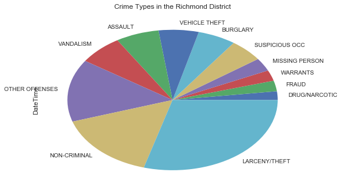

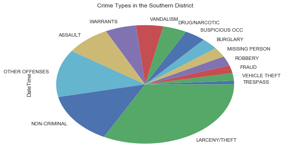

```python
collapse_category = richmond.groupby("category")
x = collapse_category.count()
x = pd.DataFrame(x['DateTime'])
x = x.sort('DateTime')
x = x.iloc[25:]

x['DateTime'].plot.pie()
plt.title("Crime Types in the Richmond District")
plt.show()

query = c.execute("SELECT Category, DateTime FROM crime WHERE crime.PdDistrict = 'SOUTHERN'")
southern = query.fetchall()
southern = pd.DataFrame(southern, columns = ("category", "DateTime"))

collapse_category = southern.groupby("category")
x = collapse_category.count()
x = pd.DataFrame(x['DateTime'])
x = x.sort('DateTime')
x = x.iloc[25:]

x['DateTime'].plot.pie()
plt.title("Crime Types in the Southern District")
plt.show()
```